# COVID-19: First and Second Digits Analysis

David Jackson

02/01/2021 03:30 PM/EST

## Benford’s Law Analysis for New Yoirk and Selected US States (Cases and Deaths)

### Is New York State “Cooking their Books” for Covid19 Deaths?

#### Comparing New York State to:

- New York, Texas,Florida,Illinois,Pennsylvania,Ohio,California,Georgia

- *N.Y. Severely Undercounted Virus Deaths in Nursing Homes*
- “The state attorney general, Letitia James, said it’s likely that the Cuomo administration failed to report thousands of Covid-19 deaths of nursing home residents.”
- Source: https://www.nytimes.com/2021/01/28/nyregion/nursing-home-deaths-cuomo.html

## New York Times COVID-19 Github Repository

- *NEW-YORK-DEATHS-METHODOLOGY.md*
- “Starting with data for Aug. 6, we are switching to reporting deaths in New York State by county of residence instead of the county in which the death took place.”
- Sourcs: https://github.com/nytimes/covid-19-data/blob/master/NEW-YORK-DEATHS-METHODOLOGY.md
- Data Source: https://github.com/nytimes/covid-19-data

## Introduction:

- If based on the two quotes from the New York Times that New York State is intentionally understating the deaths in Nursing Homes.
- Analysis will be done using Benford’s Law first (1st) digit distribution.
- The conclusion, Any state that’s first digit analysis (Covid-19 Deaths) is simalar to New York State deaths is probably also “fiddling” with their deaths counts.

## Data Visualization for Covid-19 Daily Cases and Deaths

## Plot of Daily Cases by State

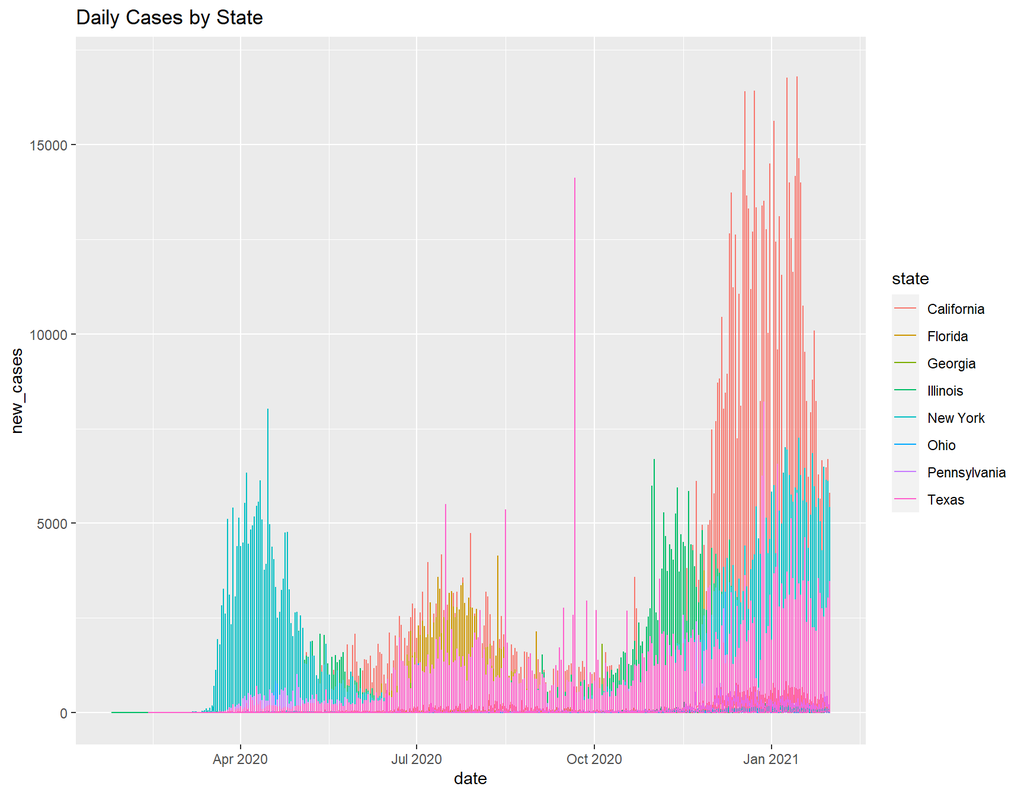

[figure not shown]

## Plot of Daily Deaths by State

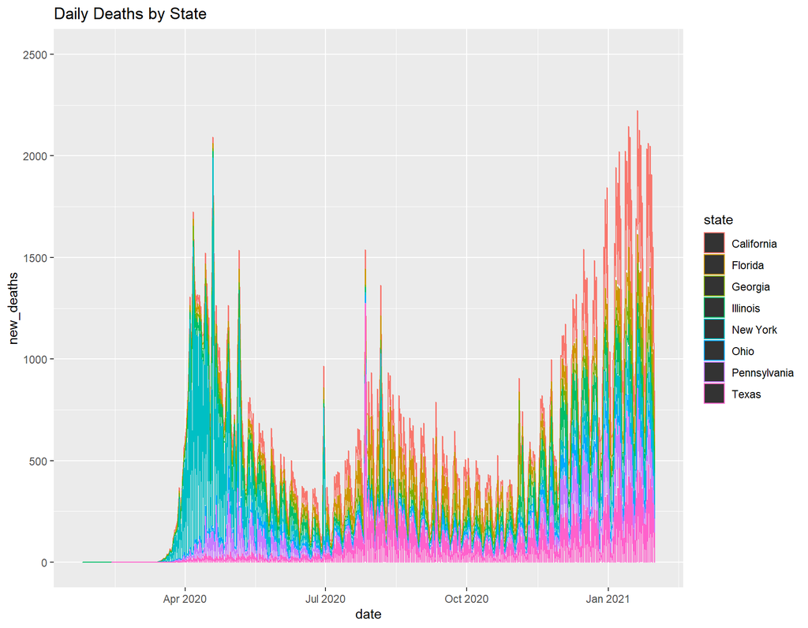

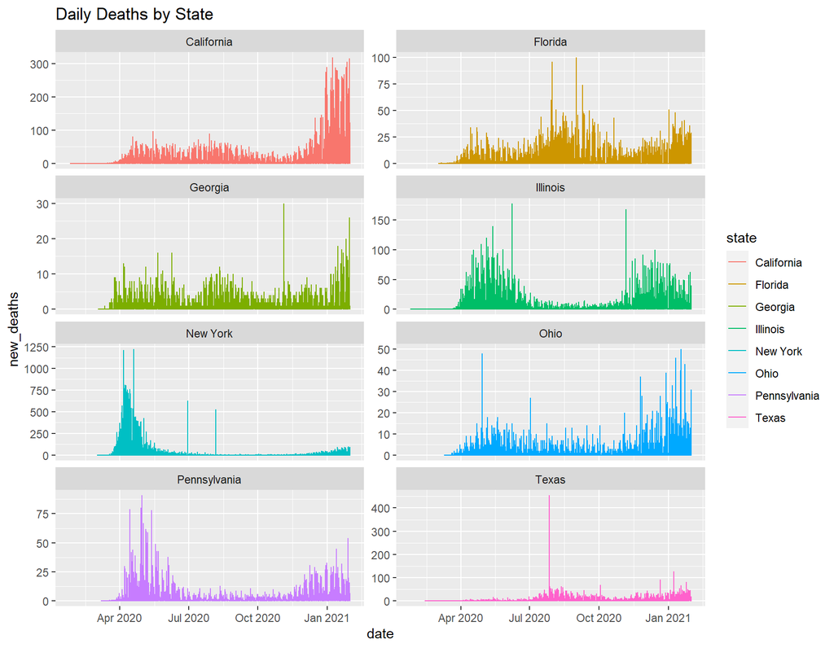

## Benford Analysis of Daily Cases by State

- Note: In general (daily) Cases match expected values better than (daily) Deaths

## New York State

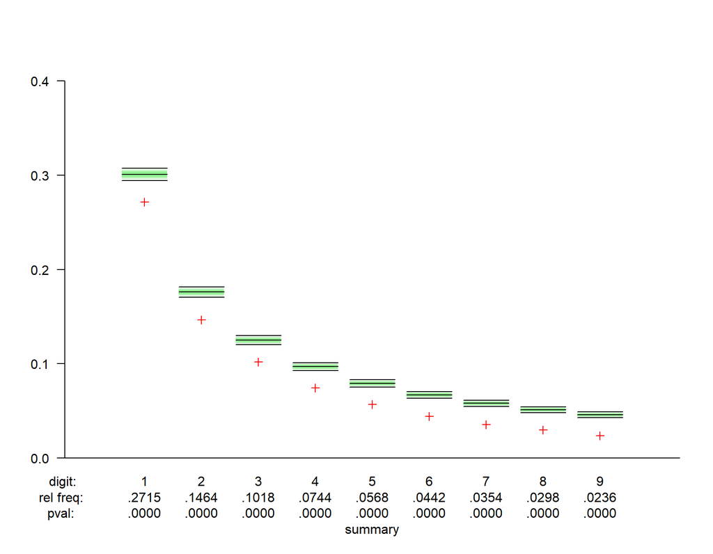

```
## $summary
##                  1            2            3            4            5
## freq  2.715264e-01 1.463849e-01 1.017954e-01 7.435165e-02 5.677468e-02
## pvals 1.961737e-18 2.371896e-26 1.539472e-21 2.910336e-25 1.298472e-29
##                  6            7            8            9
## freq  4.421200e-02 3.536960e-02 2.981614e-02 2.356176e-02
## pvals 3.026071e-35 1.122074e-39 1.009534e-39 1.989559e-47
##
## $CIs
##               1         2         3          4          5          6          7
## 0.025 0.2944285 0.1706095 0.1201801 0.09265245 0.07529519 0.06334988 0.05462821
## 0.5   0.3010300 0.1760913 0.1249387 0.09691001 0.07918125 0.06694679 0.05799195
## 0.975 0.3076315 0.1815730 0.1296973 0.10116758 0.08306731 0.07054370 0.06135569
##                8          9
## 0.025 0.04798191 0.04275023
## 0.5   0.05115252 0.04575749
## 0.975 0.05432313 0.04876476
```

#### Mean Absolute Deviation (MAD)

```
## [1] 0.009350405
```

## California

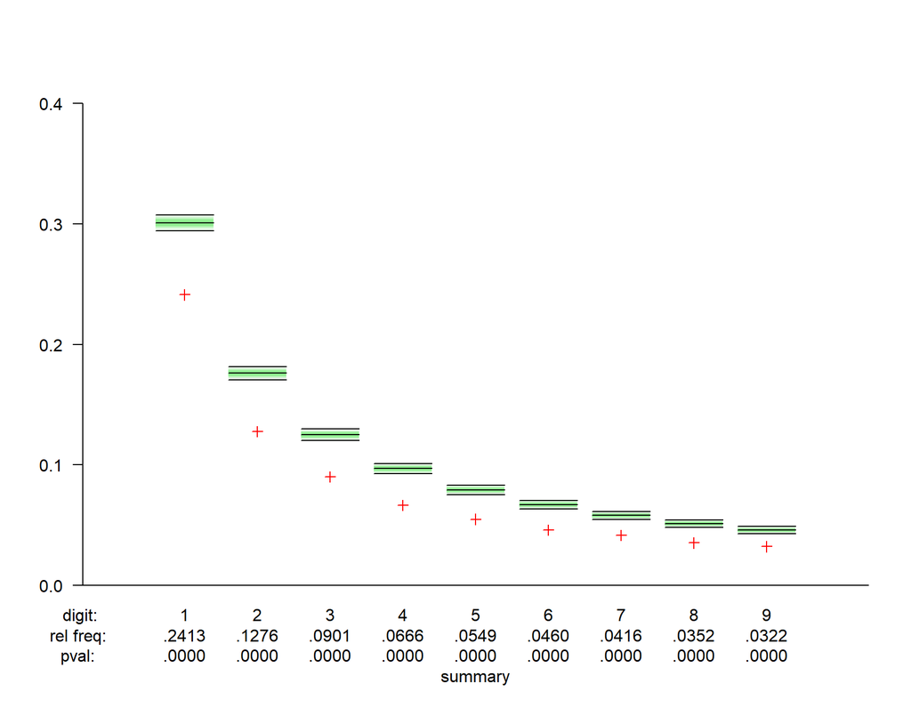

```
## $summary
##                  1            2            3            4            5
## freq  2.412621e-01 1.276160e-01 9.012945e-02 6.655879e-02 5.485437e-02
## pvals 2.007907e-70 2.855406e-67 1.332242e-46 2.392647e-44 1.359879e-34
##                  6           7            8            9
## freq  4.600863e-02 4.16397e-02 3.522114e-02 3.220065e-02
## pvals 3.853592e-30 1.63094e-21 7.105872e-23 1.010791e-18
##
## $CIs
##               1         2         3          4          5          6          7
## 0.025 0.2944272 0.1706085 0.1201792 0.09265165 0.07529445 0.06334920 0.05462757
## 0.5   0.3010300 0.1760913 0.1249387 0.09691001 0.07918125 0.06694679 0.05799195
## 0.975 0.3076328 0.1815740 0.1296982 0.10116838 0.08306804 0.07054438 0.06135632
##                8          9
## 0.025 0.04798131 0.04274966
## 0.5   0.05115252 0.04575749
## 0.975 0.05432373 0.04876532
```

- Mean Absolute Deviation (MAD)

```
## [1] 0.005598419
```

## Texas

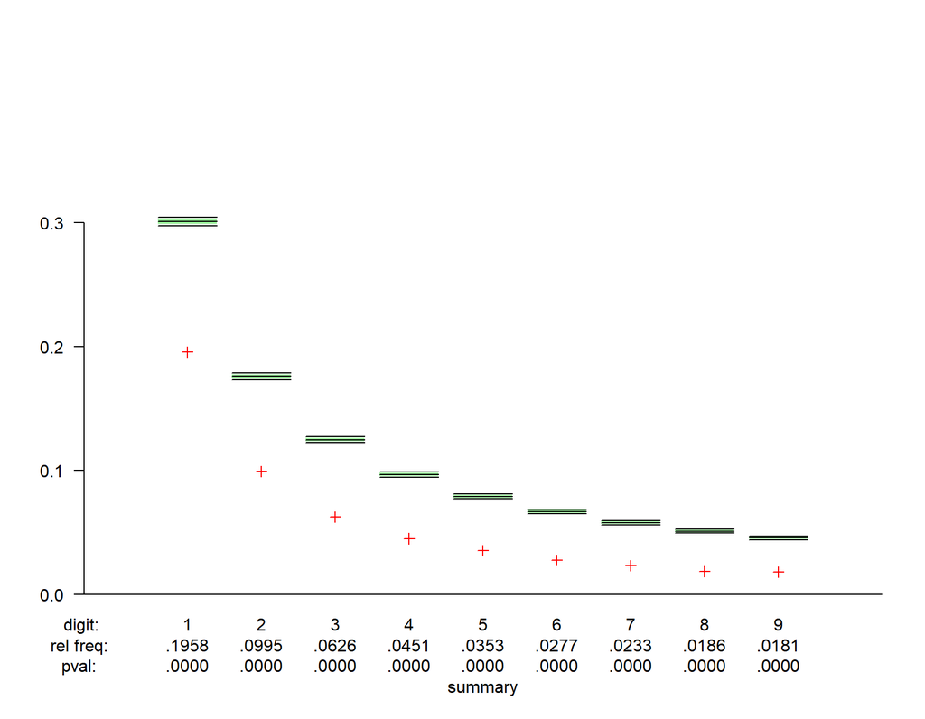

```
## $summary
##               1          2          3          4          5          6
## freq  0.1957626 0.09947602 0.06255612 0.04508114 0.03533858 0.02774018
## pvals 0.0000000 0.00000000 0.00000000 0.00000000 0.00000000 0.00000000
##                7          8             9
## freq  0.02333123 0.01860066  1.805122e-02
## pvals 0.00000000 0.00000000 2.951978e-287
##
## $CIs
##               1         2         3          4          5          6          7
## 0.025 0.2977388 0.1733583 0.1225664 0.09478742 0.07724386 0.06515356 0.05631496
## 0.5   0.3010300 0.1760913 0.1249387 0.09691001 0.07918125 0.06694679 0.05799195
## 0.975 0.3043212 0.1788242 0.1273111 0.09903261 0.08111863 0.06874002 0.05966893
##                8          9
## 0.025 0.04957182 0.04425823
## 0.5   0.05115252 0.04575749
## 0.975 0.05273322 0.04725675
```

- Mean Absolute Deviation (MAD)

```
## [1] 0.01108324
```

## Florida

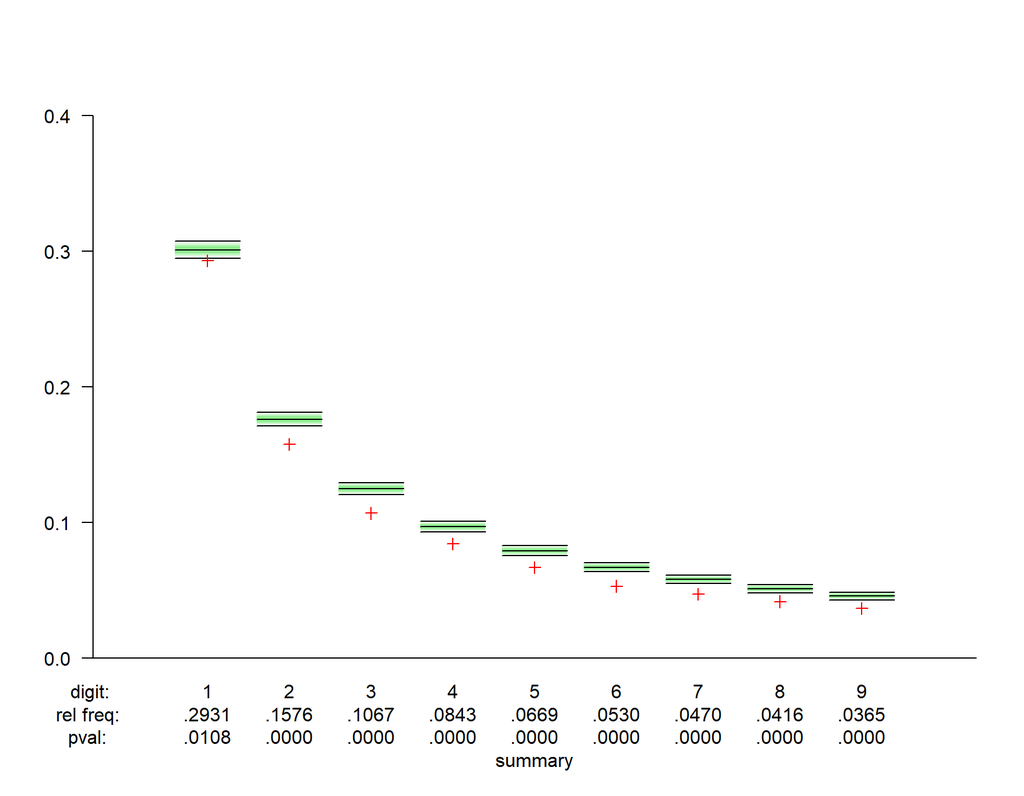

```
## $summary
##                1            2            3            4            5
## freq  0.29306342 1.575819e-01 1.067416e-01 8.431609e-02 6.685858e-02
## pvals 0.01080864 9.923838e-13 6.649584e-16 4.167852e-10 2.120923e-11
##                  6            7            8            9
## freq  5.297614e-02 4.703315e-02 4.164732e-02 3.654007e-02
## pvals 2.334080e-16 5.941515e-12 2.422009e-10 9.564017e-11
##
## $CIs
##              1         2         3          4          5          6          7
## 0.025 0.294904 0.1710044 0.1205229 0.09295912 0.07557510 0.06360897 0.05487050
## 0.5   0.301030 0.1760913 0.1249387 0.09691001 0.07918125 0.06694679 0.05799195
## 0.975 0.307156 0.1811782 0.1293546 0.10086091 0.08278739 0.07028461 0.06111340
##                8          9
## 0.025 0.04821029 0.04296684
## 0.5   0.05115252 0.04575749
## 0.975 0.05409476 0.04854814
```

[output not shown]

- Mean Absolute Deviation (MAD)

```
## [1] 0.007006085
```

## Illinois

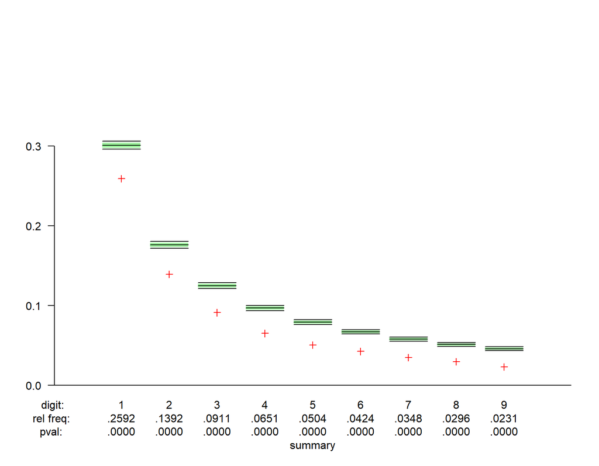

```
## $summary
##                  1            2            3            4            5
## freq  2.592498e-01 1.391782e-01 9.112403e-02 6.505208e-02 5.038661e-02
## pvals 2.044898e-58 6.886620e-66 3.658299e-73 6.401377e-81 2.185801e-79
##                  6            7            8            9
## freq  4.239888e-02 3.479456e-02 2.958656e-02 2.313247e-02
## pvals 1.249645e-67 5.125158e-69 3.446430e-67 8.757829e-82
##
## $CIs
##               1         2         3          4          5          6          7
## 0.025 0.2959481 0.1718714 0.1212756 0.09363254 0.07618975 0.06417789 0.05540254
## 0.5   0.3010300 0.1760913 0.1249387 0.09691001 0.07918125 0.06694679 0.05799195
## 0.975 0.3061119 0.1803111 0.1286019 0.10018749 0.08217274 0.06971569 0.06058136
##                8          9
## 0.025 0.04871178 0.04344249
## 0.5   0.05115252 0.04575749
## 0.975 0.05359326 0.04807249
```

- Mean Absolute Deviation (MAD)

[output not shown]

## Pennsylvania

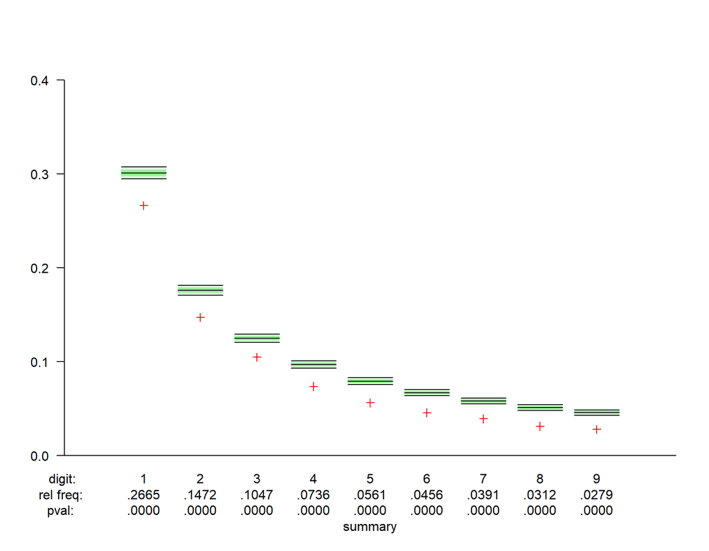

```
## $summary
##                  1            2            3            4            5
## freq  2.664580e-01 1.472206e-01 1.047240e-01 7.356289e-02 5.610890e-02
## pvals 7.117481e-28 3.580685e-28 6.854388e-19 2.110913e-30 2.391782e-35
##                  6           7            8            9
## freq  4.557959e-02 3.91292e-02 3.120850e-02 2.788845e-02
## pvals 2.198535e-35 1.02525e-31 1.820275e-39 2.112881e-35
##
## $CIs
##               1         2         3          4          5          6          7
## 0.025 0.2948384 0.1709499 0.1204756 0.09291681 0.07553648 0.06357322 0.05483707
## 0.5   0.3010300 0.1760913 0.1249387 0.09691001 0.07918125 0.06694679 0.05799195
## 0.975 0.3072216 0.1812326 0.1294019 0.10090322 0.08282601 0.07032036 0.06114683
##                8          9
## 0.025 0.04817878 0.04293695
## 0.5   0.05115252 0.04575749
## 0.975 0.05412626 0.04857803
```

- Mean Absolute Deviation (MAD)

```
## [1] 0.008397726
```

## Ohio

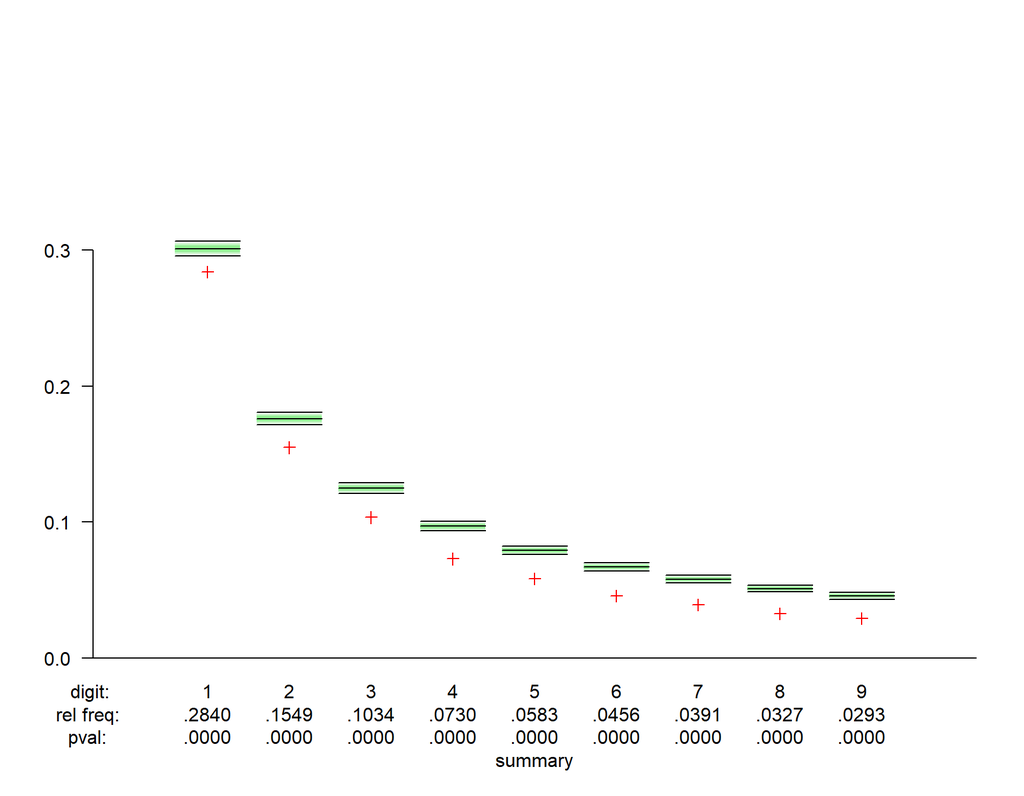

```
## $summary
##                  1            2            3            4            5
## freq  2.839780e-01 1.548706e-01 1.034169e-01 7.295950e-02 5.829482e-02
## pvals 7.160628e-10 2.568022e-20 3.831425e-27 4.562122e-41 1.222413e-37
##                  6            7            8            9
## freq  4.563153e-02 3.908155e-02 3.271351e-02 2.929297e-02
## pvals 2.213991e-45 5.117050e-41 9.022728e-44 5.438359e-39
##
## $CIs
##               1         2         3          4          5          6          7
## 0.025 0.2956067 0.1715879 0.1210294 0.09341232 0.07598875 0.06399184 0.05522855
## 0.5   0.3010300 0.1760913 0.1249387 0.09691001 0.07918125 0.06694679 0.05799195
## 0.975 0.3064533 0.1805947 0.1288480 0.10040771 0.08237374 0.06990174 0.06075534
##                8          9
## 0.025 0.04854779 0.04328695
## 0.5   0.05115252 0.04575749
## 0.975 0.05375726 0.04822803
```

- Mean Absolute Deviation (MAD)

```
## [1] 0.009269571
```

## California

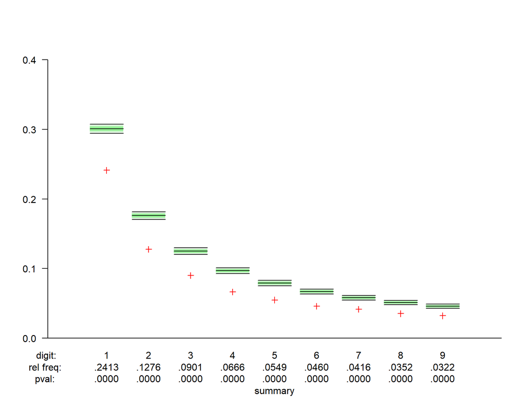

```
## $summary
##                  1            2            3            4            5
## freq  2.412621e-01 1.276160e-01 9.012945e-02 6.655879e-02 5.485437e-02
## pvals 2.007907e-70 2.855406e-67 1.332242e-46 2.392647e-44 1.359879e-34
##                  6           7            8            9
## freq  4.600863e-02 4.16397e-02 3.522114e-02 3.220065e-02
## pvals 3.853592e-30 1.63094e-21 7.105872e-23 1.010791e-18
##
## $CIs
##               1         2         3          4          5          6          7
## 0.025 0.2944272 0.1706085 0.1201792 0.09265165 0.07529445 0.06334920 0.05462757
## 0.5   0.3010300 0.1760913 0.1249387 0.09691001 0.07918125 0.06694679 0.05799195
## 0.975 0.3076328 0.1815740 0.1296982 0.10116838 0.08306804 0.07054438 0.06135632
##                8          9
## 0.025 0.04798131 0.04274966
## 0.5   0.05115252 0.04575749
## 0.975 0.05432373 0.04876532
```

- Mean Absolute Deviation (MAD)

```
## [1] 0.005598419
```

## Georgia

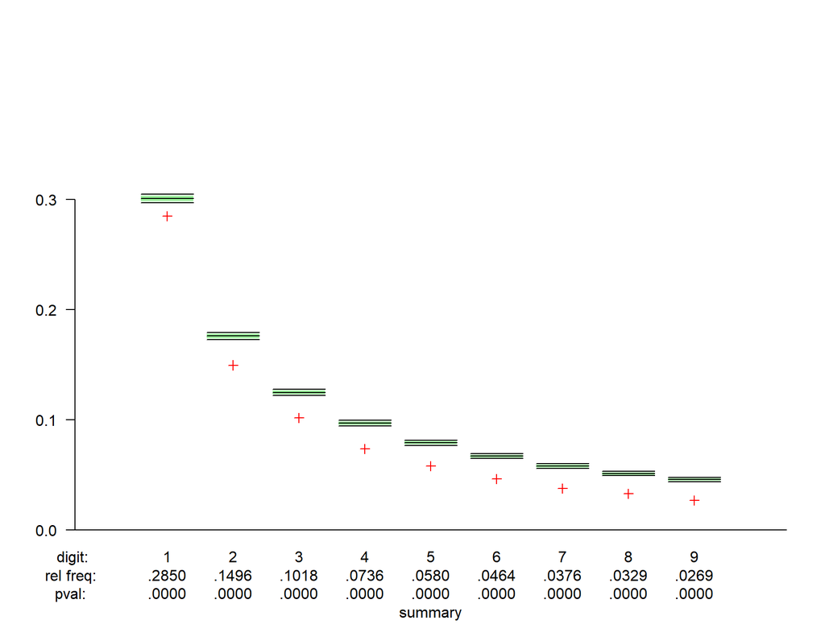

```
## $summary
##                  1            2            3            4            5
## freq  2.849687e-01 1.496131e-01 1.018217e-01 7.364674e-02 5.800956e-02
## pvals 4.872692e-15 1.707597e-54 4.225951e-55 3.203805e-69 7.880620e-69
##                  6            7            8            9
## freq  4.641165e-02 3.757324e-02 3.293407e-02 2.689516e-02
## pvals 2.121763e-75 5.400577e-85 2.357686e-76 1.289099e-90
##
## $CIs
##               1         2         3          4          5          6          7
## 0.025 0.2970097 0.1727529 0.1220408 0.09431718 0.07681466 0.06475630 0.05594345
## 0.5   0.3010300 0.1760913 0.1249387 0.09691001 0.07918125 0.06694679 0.05799195
## 0.975 0.3050503 0.1794296 0.1278367 0.09950284 0.08154783 0.06913728 0.06004044
##                8          9
## 0.025 0.04922164 0.04392609
## 0.5   0.05115252 0.04575749
## 0.975 0.05308340 0.04758890
```

- Mean Absolute Deviation (MAD)

```
## [1] 0.01203704
```

## Benford Analysis of Daily Deaths by State

## New York State

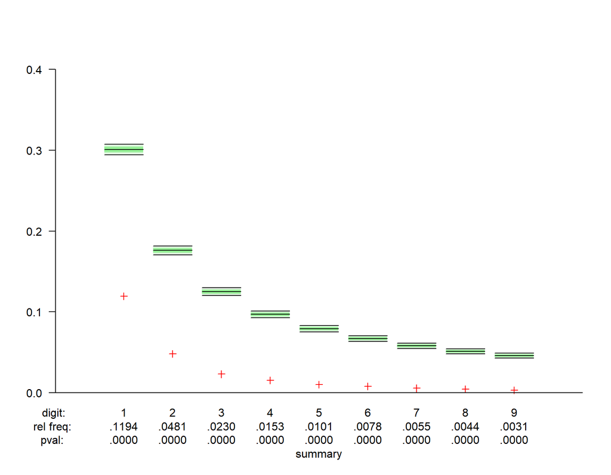

```
## $summary
##               1          2          3          4             5             6
## freq  0.1193724 0.04814795 0.02296867 0.01531245  1.008249e-02  7.764059e-03
## pvals 0.0000000 0.00000000 0.00000000 0.00000000 4.186528e-266 3.655215e-228
##                   7             8             9
## freq   5.499542e-03  4.421200e-03  3.127190e-03
## pvals 1.881339e-205 1.703461e-183 6.770909e-170
##
## $CIs
##               1         2         3          4          5          6          7
## 0.025 0.2944285 0.1706095 0.1201801 0.09265245 0.07529519 0.06334988 0.05462821
## 0.5   0.3010300 0.1760913 0.1249387 0.09691001 0.07918125 0.06694679 0.05799195
## 0.975 0.3076315 0.1815730 0.1296973 0.10116758 0.08306731 0.07054370 0.06135569
##                8          9
## 0.025 0.04798191 0.04275023
## 0.5   0.05115252 0.04575749
## 0.975 0.05432313 0.04876476
```

#### Mean Absolute Deviation (MAD)

```
## [1] 0.01707761
```

## California

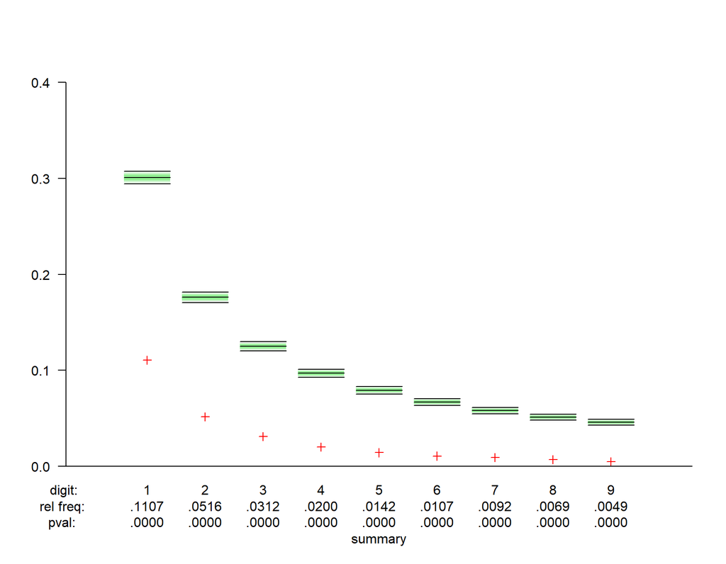

```
## $summary
##               1          2          3             4             5             6
## freq  0.1106796 0.05161812 0.03117584  2.001079e-02  1.423948e-02  1.067961e-02
## pvals 0.0000000 0.00000000 0.00000000 2.128106e-274 3.274833e-235 2.313450e-206
##                   7             8             9
## freq   9.223301e-03  6.903991e-03  4.854369e-03
## pvals 1.484717e-177 1.147755e-164 1.639203e-156
##
## $CIs
##               1         2         3          4          5          6          7
## 0.025 0.2944272 0.1706085 0.1201792 0.09265165 0.07529445 0.06334920 0.05462757
## 0.5   0.3010300 0.1760913 0.1249387 0.09691001 0.07918125 0.06694679 0.05799195
## 0.975 0.3076328 0.1815740 0.1296982 0.10116838 0.08306804 0.07054438 0.06135632
##                8          9
## 0.025 0.04798131 0.04274966
## 0.5   0.05115252 0.04575749
## 0.975 0.05432373 0.04876532
```

- Mean Absolute Deviation (MAD)

```
## [1] 0.01596716
```

## Texas

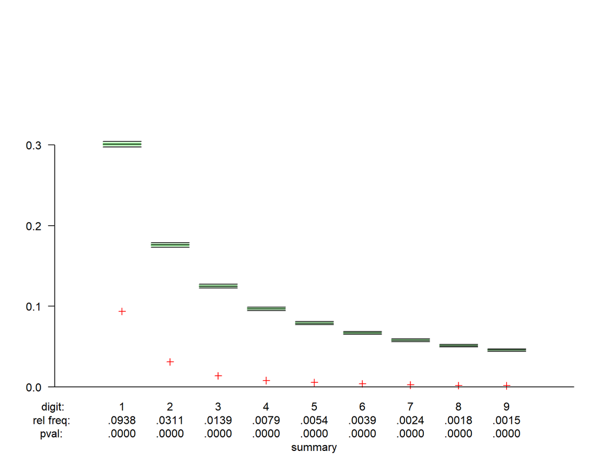

```
## $summary
##                1          2          3           4           5           6
## freq  0.09375377 0.03110384 0.01392369 0.007933424 0.005440828 0.003899707
## pvals 0.00000000 0.00000000 0.00000000 0.000000000 0.000000000 0.000000000
##                 7           8          9
## freq  0.002425591 0.001822543 0.00152772
## pvals 0.000000000 0.000000000 0.00000000
##
## $CIs
##               1         2         3          4          5          6          7
## 0.025 0.2977388 0.1733583 0.1225664 0.09478742 0.07724386 0.06515356 0.05631496
## 0.5   0.3010300 0.1760913 0.1249387 0.09691001 0.07918125 0.06694679 0.05799195
## 0.975 0.3043212 0.1788242 0.1273111 0.09903261 0.08111863 0.06874002 0.05966893
##                8          9
## 0.025 0.04957182 0.04425823
## 0.5   0.05115252 0.04575749
## 0.975 0.05273322 0.04725675
```

- Mean Absolute Deviation (MAD)

```
## [1] 0.01851608
```

## Florida

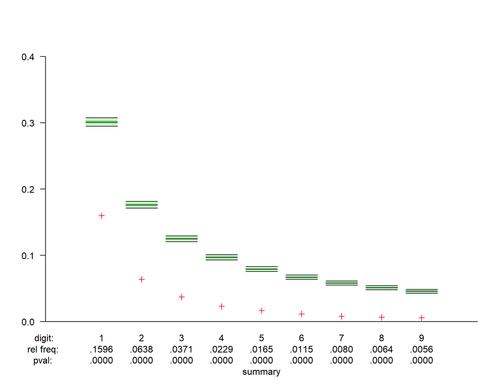

```
## $summary
##               1          2          3             4             5             6
## freq  0.1595784 0.06384065 0.03705079  2.293621e-02  1.648250e-02  1.151453e-02
## pvals 0.0000000 0.00000000 0.00000000 8.147209e-295 1.608178e-254 2.113459e-232
##                   7             8             9
## freq   8.032315e-03  6.407280e-03  5.571548e-03
## pvals 5.237208e-216 3.173165e-195 2.980593e-175
##
## $CIs
##              1         2         3          4          5          6          7
## 0.025 0.294904 0.1710044 0.1205229 0.09295912 0.07557510 0.06360897 0.05487050
## 0.5   0.301030 0.1760913 0.1249387 0.09691001 0.07918125 0.06694679 0.05799195
## 0.975 0.307156 0.1811782 0.1293546 0.10086091 0.08278739 0.07028461 0.06111340
##                8          9
## 0.025 0.04821029 0.04296684
## 0.5   0.05115252 0.04575749
## 0.975 0.05409476 0.04854814
```

[output not shown]

- Mean Absolute Deviation (MAD)

```
## [1] 0.01794231
```

## Illinois

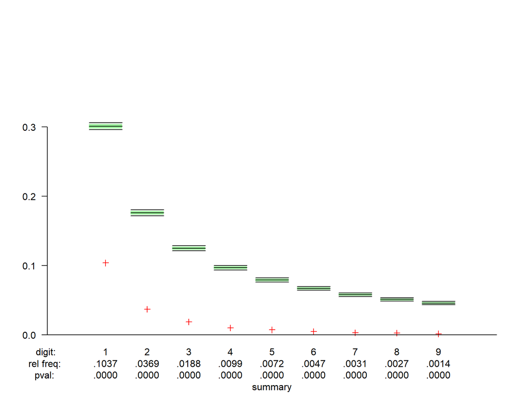

```
## $summary
##               1          2          3           4           5           6
## freq  0.1037446 0.03687137 0.01881909 0.009904786 0.007188958 0.004728737
## pvals 0.0000000 0.00000000 0.00000000 0.000000000 0.000000000 0.000000000
##                7           8           9
## freq  0.00309924 0.002715828 0.001437792
## pvals 0.00000000 0.000000000 0.000000000
##
## $CIs
##               1         2         3          4          5          6          7
## 0.025 0.2959481 0.1718714 0.1212756 0.09363254 0.07618975 0.06417789 0.05540254
## 0.5   0.3010300 0.1760913 0.1249387 0.09691001 0.07918125 0.06694679 0.05799195
## 0.975 0.3061119 0.1803111 0.1286019 0.10018749 0.08217274 0.06971569 0.06058136
##                8          9
## 0.025 0.04871178 0.04344249
## 0.5   0.05115252 0.04575749
## 0.975 0.05359326 0.04807249
```

- Mean Absolute Deviation (MAD)

[output not shown]

## Pennsylvania

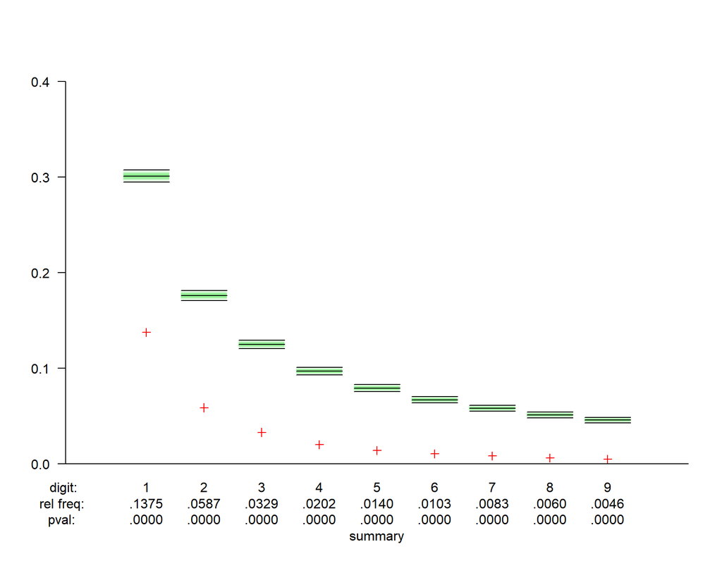

```
## $summary
##               1          2          3          4             5             6
## freq  0.1375451 0.05867008 0.03291596 0.02015747  1.399165e-02  1.033959e-02
## pvals 0.0000000 0.00000000 0.00000000 0.00000000 3.211610e-269 3.323534e-237
##                   7             8             9
## freq   8.252703e-03  5.976096e-03  4.648074e-03
## pvals 1.178665e-209 8.151655e-195 1.751474e-179
##
## $CIs
##               1         2         3          4          5          6          7
## 0.025 0.2948384 0.1709499 0.1204756 0.09291681 0.07553648 0.06357322 0.05483707
## 0.5   0.3010300 0.1760913 0.1249387 0.09691001 0.07918125 0.06694679 0.05799195
## 0.975 0.3072216 0.1812326 0.1294019 0.10090322 0.08282601 0.07032036 0.06114683
##                8          9
## 0.025 0.04817878 0.04293695
## 0.5   0.05115252 0.04575749
## 0.975 0.05412626 0.04857803
```

- Mean Absolute Deviation (MAD)

```
## [1] 0.01831859
```

## Ohio

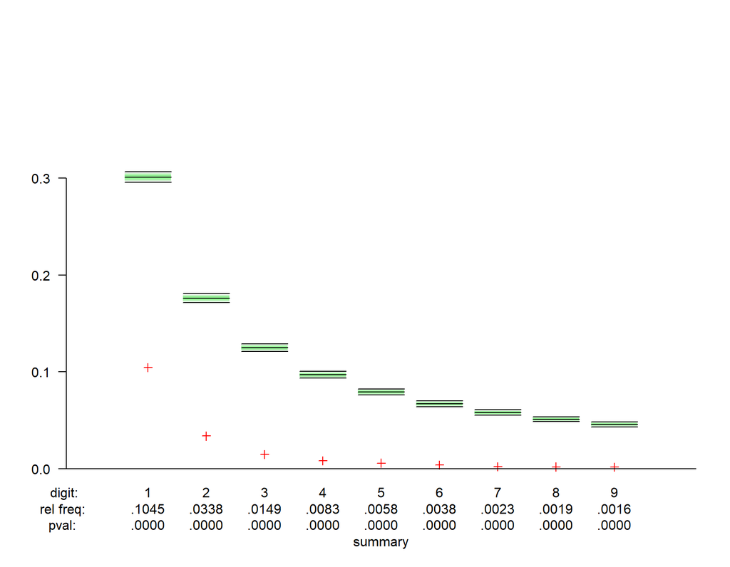

```
## $summary
##               1          2         3          4           5           6
## freq  0.1044722 0.03380517 0.0149194 0.00833303 0.005822204 0.003820822
## pvals 0.0000000 0.00000000 0.0000000 0.00000000 0.000000000 0.000000000
##                 7             8             9
## freq  0.002256104  1.892216e-03  1.601106e-03
## pvals 0.000000000 9.737441e-301 7.661771e-269
##
## $CIs
##               1         2         3          4          5          6          7
## 0.025 0.2956067 0.1715879 0.1210294 0.09341232 0.07598875 0.06399184 0.05522855
## 0.5   0.3010300 0.1760913 0.1249387 0.09691001 0.07918125 0.06694679 0.05799195
## 0.975 0.3064533 0.1805947 0.1288480 0.10040771 0.08237374 0.06990174 0.06075534
##                8          9
## 0.025 0.04854779 0.04328695
## 0.5   0.05115252 0.04575749
## 0.975 0.05375726 0.04822803
```

- Mean Absolute Deviation (MAD)

```
## [1] 0.01907979
```

## California

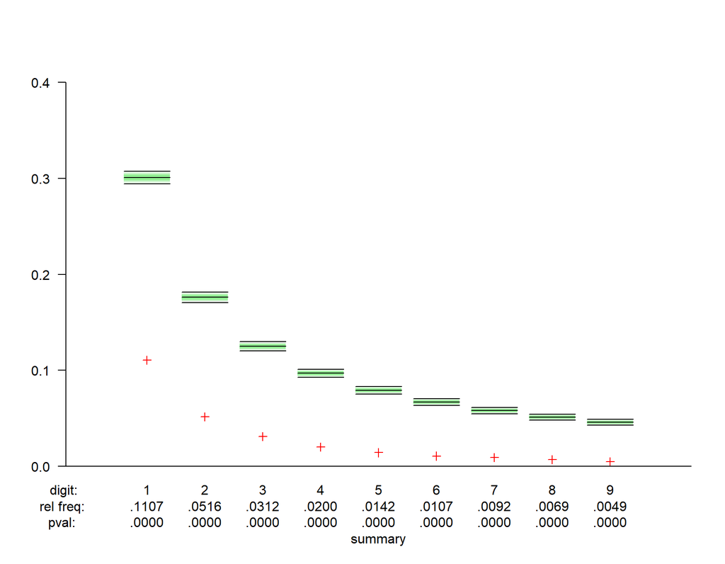

```
## $summary
##               1          2          3             4             5             6
## freq  0.1106796 0.05161812 0.03117584  2.001079e-02  1.423948e-02  1.067961e-02
## pvals 0.0000000 0.00000000 0.00000000 2.128106e-274 3.274833e-235 2.313450e-206
##                   7             8             9
## freq   9.223301e-03  6.903991e-03  4.854369e-03
## pvals 1.484717e-177 1.147755e-164 1.639203e-156
##
## $CIs
##               1         2         3          4          5          6          7
## 0.025 0.2944272 0.1706085 0.1201792 0.09265165 0.07529445 0.06334920 0.05462757
## 0.5   0.3010300 0.1760913 0.1249387 0.09691001 0.07918125 0.06694679 0.05799195
## 0.975 0.3076328 0.1815740 0.1296982 0.10116838 0.08306804 0.07054438 0.06135632
##                8          9
## 0.025 0.04798131 0.04274966
## 0.5   0.05115252 0.04575749
## 0.975 0.05432373 0.04876532
```

- Mean Absolute Deviation (MAD)

```
## [1] 0.01596716
```

## Georgia

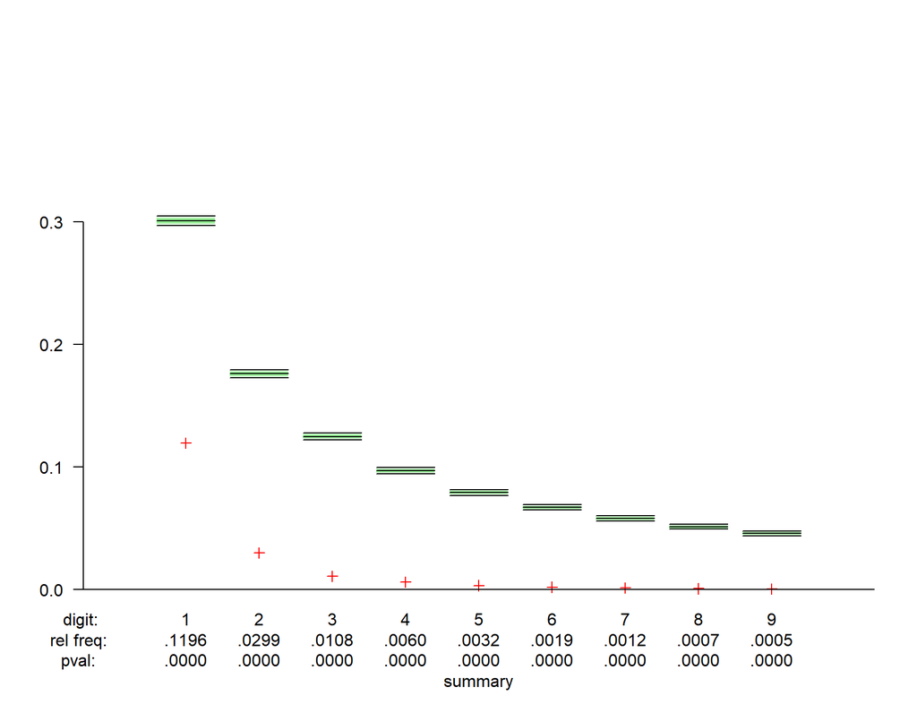

```
## $summary
##               1          2          3           4           5           6
## freq  0.1195785 0.02993461 0.01083805 0.006038913 0.003179428 0.001919654
## pvals 0.0000000 0.00000000 0.00000000 0.000000000 0.000000000 0.000000000
##                 7            8            9
## freq  0.001179788 0.0006798776 0.0004599172
## pvals 0.000000000 0.0000000000 0.0000000000
##
## $CIs
##               1         2         3          4          5          6          7
## 0.025 0.2970097 0.1727529 0.1220408 0.09431718 0.07681466 0.06475630 0.05594345
## 0.5   0.3010300 0.1760913 0.1249387 0.09691001 0.07918125 0.06694679 0.05799195
## 0.975 0.3050503 0.1794296 0.1278367 0.09950284 0.08154783 0.06913728 0.06004044
##                8          9
## 0.025 0.04922164 0.04392609
## 0.5   0.05115252 0.04575749
## 0.975 0.05308340 0.04758890
```

- Mean Absolute Deviation (MAD)

```
## [1] 0.01953859
```